# Risk Factor Analysis

## Outcome Variable

**Outcome Variable:** whz

## Predictor Variables

**Intervention Variable:** exclfeed3

**Adjustment Set:**

- arm
- sex
- brthmon
- W_mage
- meducyrs
- feducyrs
- hhwealth_quart
- hfoodsec
- W_mhtcm
- W_mwtkg
- W_mbmi
- vagbrth
- W_gagebrth
- W_birthwt
- W_birthlen
- W_nrooms
- W_nchldlt5
- month
- W_parity
- impfloor
- impsan
- safeh20
- delta_W_mage
- delta_meducyrs
- delta_feducyrs
- delta_hhwealth_quart
- delta_hfoodsec
- delta_W_mhtcm
- delta_W_mwtkg
- delta_W_mbmi
- delta_vagbrth
- delta_W_gagebrth
- delta_W_birthwt
- delta_W_birthlen
- delta_W_nrooms
- delta_W_nchldlt5
- delta_month
- delta_W_parity
- delta_impfloor
- delta_impsan
- delta_safeh20

## Stratifying Variables

The analysis was stratified on these variable(s):

- agecat
- studyid
- country

## Data Summary

| agecat | studyid | country | exclfeed3 | n_cell | n | outcome_variable |
| --- | --- | --- | --- | --- | --- | --- |
| Birth | CMC-V-BCS-2002 | INDIA | 1 | 4 | 4 | whz |
| Birth | CMC-V-BCS-2002 | INDIA | 0 | 0 | 4 | whz |
| Birth | EE | PAKISTAN | 1 | 22 | 22 | whz |
| Birth | EE | PAKISTAN | 0 | 0 | 22 | whz |
| Birth | GMS-Nepal | NEPAL | 1 | 352 | 422 | whz |
| Birth | GMS-Nepal | NEPAL | 0 | 70 | 422 | whz |
| Birth | IRC | INDIA | 1 | 0 | 9 | whz |
| Birth | IRC | INDIA | 0 | 9 | 9 | whz |
| Birth | JiVitA-3 | BANGLADESH | 1 | 9636 | 10634 | whz |
| Birth | JiVitA-3 | BANGLADESH | 0 | 998 | 10634 | whz |
| Birth | JiVitA-4 | BANGLADESH | 1 | 89 | 97 | whz |
| Birth | JiVitA-4 | BANGLADESH | 0 | 8 | 97 | whz |
| Birth | Keneba | GAMBIA | 1 | 1133 | 1282 | whz |
| Birth | Keneba | GAMBIA | 0 | 149 | 1282 | whz |
| Birth | MAL-ED | BANGLADESH | 1 | 130 | 202 | whz |
| Birth | MAL-ED | BANGLADESH | 0 | 72 | 202 | whz |
| Birth | MAL-ED | BRAZIL | 1 | 11 | 55 | whz |
| Birth | MAL-ED | BRAZIL | 0 | 44 | 55 | whz |
| Birth | MAL-ED | INDIA | 1 | 22 | 39 | whz |
| Birth | MAL-ED | INDIA | 0 | 17 | 39 | whz |
| Birth | MAL-ED | NEPAL | 1 | 8 | 25 | whz |
| Birth | MAL-ED | NEPAL | 0 | 17 | 25 | whz |
| Birth | MAL-ED | PERU | 1 | 47 | 218 | whz |
| Birth | MAL-ED | PERU | 0 | 171 | 218 | whz |
| Birth | MAL-ED | SOUTH AFRICA | 1 | 12 | 99 | whz |
| Birth | MAL-ED | SOUTH AFRICA | 0 | 87 | 99 | whz |
| Birth | MAL-ED | TANZANIA, UNITED REPUBLIC OF | 1 | 15 | 95 | whz |
| Birth | MAL-ED | TANZANIA, UNITED REPUBLIC OF | 0 | 80 | 95 | whz |
| Birth | PROVIDE | BANGLADESH | 1 | 381 | 532 | whz |
| Birth | PROVIDE | BANGLADESH | 0 | 151 | 532 | whz |

[output cut: 64 more lines]

The following strata were considered:

- agecat: 24 months, studyid: CMC-V-BCS-2002, country: INDIA
- agecat: 24 months, studyid: EE, country: PAKISTAN
- agecat: 24 months, studyid: GMS-Nepal, country: NEPAL
- agecat: 24 months, studyid: IRC, country: INDIA
- agecat: 24 months, studyid: JiVitA-3, country: BANGLADESH
- agecat: 24 months, studyid: JiVitA-4, country: BANGLADESH
- agecat: 24 months, studyid: Keneba, country: GAMBIA
- agecat: 24 months, studyid: MAL-ED, country: BANGLADESH
- agecat: 24 months, studyid: MAL-ED, country: BRAZIL
- agecat: 24 months, studyid: MAL-ED, country: INDIA
- agecat: 24 months, studyid: MAL-ED, country: NEPAL
- agecat: 24 months, studyid: MAL-ED, country: PERU
- agecat: 24 months, studyid: MAL-ED, country: SOUTH AFRICA
- agecat: 24 months, studyid: MAL-ED, country: TANZANIA, UNITED REPUBLIC OF
- agecat: 24 months, studyid: PROVIDE, country: BANGLADESH
- agecat: 6 months, studyid: CMC-V-BCS-2002, country: INDIA
- agecat: 6 months, studyid: EE, country: PAKISTAN
- agecat: 6 months, studyid: GMS-Nepal, country: NEPAL
- agecat: 6 months, studyid: IRC, country: INDIA
- agecat: 6 months, studyid: JiVitA-3, country: BANGLADESH
- agecat: 6 months, studyid: JiVitA-4, country: BANGLADESH
- agecat: 6 months, studyid: Keneba, country: GAMBIA
- agecat: 6 months, studyid: MAL-ED, country: BANGLADESH
- agecat: 6 months, studyid: MAL-ED, country: BRAZIL
- agecat: 6 months, studyid: MAL-ED, country: INDIA
- agecat: 6 months, studyid: MAL-ED, country: NEPAL
- agecat: 6 months, studyid: MAL-ED, country: PERU
- agecat: 6 months, studyid: MAL-ED, country: SOUTH AFRICA
- agecat: 6 months, studyid: MAL-ED, country: TANZANIA, UNITED REPUBLIC OF
- agecat: 6 months, studyid: PROVIDE, country: BANGLADESH
- agecat: 6 months, studyid: SAS-CompFeed, country: INDIA
- agecat: Birth, studyid: CMC-V-BCS-2002, country: INDIA
- agecat: Birth, studyid: EE, country: PAKISTAN
- agecat: Birth, studyid: GMS-Nepal, country: NEPAL
- agecat: Birth, studyid: IRC, country: INDIA
- agecat: Birth, studyid: JiVitA-3, country: BANGLADESH
- agecat: Birth, studyid: JiVitA-4, country: BANGLADESH
- agecat: Birth, studyid: Keneba, country: GAMBIA
- agecat: Birth, studyid: MAL-ED, country: BANGLADESH
- agecat: Birth, studyid: MAL-ED, country: BRAZIL
- agecat: Birth, studyid: MAL-ED, country: INDIA
- agecat: Birth, studyid: MAL-ED, country: NEPAL
- agecat: Birth, studyid: MAL-ED, country: PERU
- agecat: Birth, studyid: MAL-ED, country: SOUTH AFRICA
- agecat: Birth, studyid: MAL-ED, country: TANZANIA, UNITED REPUBLIC OF
- agecat: Birth, studyid: PROVIDE, country: BANGLADESH
- agecat: Birth, studyid: SAS-CompFeed, country: INDIA

### Dropped Strata

Some strata were dropped due to rare outcomes:

- agecat: Birth, studyid: CMC-V-BCS-2002, country: INDIA
- agecat: Birth, studyid: EE, country: PAKISTAN
- agecat: Birth, studyid: IRC, country: INDIA
- agecat: 6 months, studyid: CMC-V-BCS-2002, country: INDIA
- agecat: 6 months, studyid: EE, country: PAKISTAN
- agecat: 6 months, studyid: IRC, country: INDIA
- agecat: 24 months, studyid: CMC-V-BCS-2002, country: INDIA
- agecat: 24 months, studyid: EE, country: PAKISTAN
- agecat: 24 months, studyid: IRC, country: INDIA

## Methods Detail

We’re interested in the causal parameters $E[Y_a]$ for all values of $a \in \mathcal{A}$. These parameters represent the mean outcome if, possibly contrary to fact, we intervened to set all units to have $A=a$. Under the randomization and positivity assumptions, these are identified by the statistical parameters $\psi_a=E_W[E_{Y|A,W}(Y|A=a,W)]$. In addition, we’re interested in the mean of $Y$, $E[Y]$ under no intervention (the observed mean). We will estimate these parameters by using SuperLearner to fit the relevant likelihood factors – $E_{Y|A,W}(Y|A=a,W)$ and $p(A=a|W)$, and then updating our likelihood fit using a joint TMLE.

For unadjusted analyses ($W=\{\}$), initial likelihoods were estimated using Lrnr_glm to estimate the simple $E(Y|A)$ and Lrnr_mean to estimate $p(A)$. For adjusted analyses, a small library containing Lrnr_glmnet, Lrnr_xgboost, and Lrnr_mean was used.

Having estimated these parameters, we will then use the delta method to estimate relative risks and attributable risks relative to a prespecified baseline level of $A$.

# Results Detail

## Results Plots

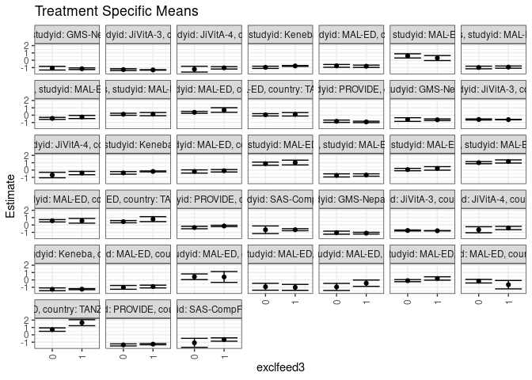

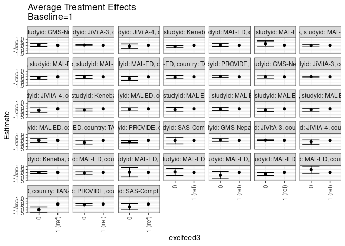

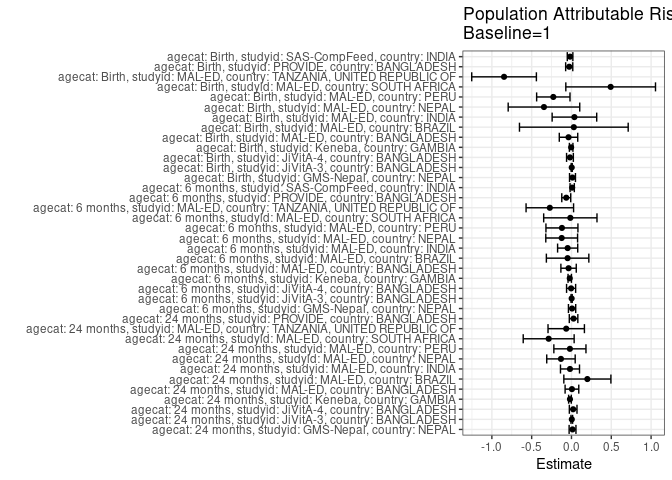

## Results Table

### Parameter: TSM

| agecat | studyid | country | intervention_level | baseline_level | estimate | ci_lower | ci_upper |
| --- | --- | --- | --- | --- | --- | --- | --- |
| Birth | GMS-Nepal | NEPAL | 1 | NA | -1.1119727 | -1.2304545 | -0.9934910 |
| Birth | GMS-Nepal | NEPAL | 0 | NA | -1.0448620 | -1.2504793 | -0.8392447 |
| Birth | JiVitA-3 | BANGLADESH | 1 | NA | -0.7829739 | -0.8062101 | -0.7597378 |
| Birth | JiVitA-3 | BANGLADESH | 0 | NA | -0.7497181 | -0.8161177 | -0.6833185 |
| Birth | JiVitA-4 | BANGLADESH | 1 | NA | -0.4156180 | -0.6383645 | -0.1928714 |
| Birth | JiVitA-4 | BANGLADESH | 0 | NA | -0.6475000 | -1.0569566 | -0.2380434 |
| Birth | Keneba | GAMBIA | 1 | NA | -1.2589995 | -1.3270783 | -1.1909208 |
| Birth | Keneba | GAMBIA | 0 | NA | -1.2808766 | -1.4702207 | -1.0915326 |
| Birth | MAL-ED | BANGLADESH | 1 | NA | -0.9038677 | -1.0913213 | -0.7164140 |
| Birth | MAL-ED | BANGLADESH | 0 | NA | -1.0149566 | -1.2741453 | -0.7557679 |
| Birth | MAL-ED | BRAZIL | 1 | NA | 0.4020983 | -0.3380116 | 1.1422082 |
| Birth | MAL-ED | BRAZIL | 0 | NA | 0.4258144 | 0.0386127 | 0.8130162 |
| Birth | MAL-ED | INDIA | 1 | NA | -1.0149177 | -1.4182957 | -0.6115396 |
| Birth | MAL-ED | INDIA | 0 | NA | -0.9353297 | -1.4017272 | -0.4689321 |
| Birth | MAL-ED | NEPAL | 1 | NA | -0.4487500 | -0.8783289 | -0.0191711 |
| Birth | MAL-ED | NEPAL | 0 | NA | -0.9570588 | -1.4394884 | -0.4746293 |
| Birth | MAL-ED | PERU | 1 | NA | 0.1945756 | -0.0337798 | 0.4229310 |
| Birth | MAL-ED | PERU | 0 | NA | -0.0992512 | -0.2414880 | 0.0429856 |
| Birth | MAL-ED | SOUTH AFRICA | 1 | NA | -0.6510843 | -1.2238730 | -0.0782957 |
| Birth | MAL-ED | SOUTH AFRICA | 0 | NA | -0.1749426 | -0.4179717 | 0.0680864 |
| Birth | MAL-ED | TANZANIA, UNITED REPUBLIC OF | 1 | NA | 1.6465131 | 1.2384420 | 2.0545843 |
| Birth | MAL-ED | TANZANIA, UNITED REPUBLIC OF | 0 | NA | 0.7070069 | 0.4750461 | 0.9389676 |
| Birth | PROVIDE | BANGLADESH | 1 | NA | -1.2700830 | -1.3578562 | -1.1823099 |
| Birth | PROVIDE | BANGLADESH | 0 | NA | -1.3744432 | -1.5156694 | -1.2332170 |
| Birth | SAS-CompFeed | INDIA | 1 | NA | -0.6419787 | -0.8661092 | -0.4178481 |
| Birth | SAS-CompFeed | INDIA | 0 | NA | -1.0901281 | -1.7027393 | -0.4775170 |
| 6 months | GMS-Nepal | NEPAL | 1 | NA | -0.6274243 | -0.7376521 | -0.5171964 |
| 6 months | GMS-Nepal | NEPAL | 0 | NA | -0.5945065 | -0.8431874 | -0.3458256 |
| 6 months | JiVitA-3 | BANGLADESH | 1 | NA | -0.6061958 | -0.6317656 | -0.5806260 |
| 6 months | JiVitA-3 | BANGLADESH | 0 | NA | -0.5845195 | -0.6616057 | -0.5074333 |
| 6 months | JiVitA-4 | BANGLADESH | 1 | NA | -0.4063089 | -0.6336553 | -0.1789626 |
| 6 months | JiVitA-4 | BANGLADESH | 0 | NA | -0.6715110 | -1.0441696 | -0.2988524 |
| 6 months | Keneba | GAMBIA | 1 | NA | -0.1839874 | -0.2423380 | -0.1256368 |
| 6 months | Keneba | GAMBIA | 0 | NA | -0.3842664 | -0.5605752 | -0.2079576 |
| 6 months | MAL-ED | BANGLADESH | 1 | NA | -0.0940613 | -0.2607951 | 0.0726725 |
| 6 months | MAL-ED | BANGLADESH | 0 | NA | -0.1888662 | -0.4052580 | 0.0275256 |
| 6 months | MAL-ED | BRAZIL | 1 | NA | 1.0241251 | 0.6994319 | 1.3488183 |
| 6 months | MAL-ED | BRAZIL | 0 | NA | 0.8747179 | 0.6642450 | 1.0851909 |
| 6 months | MAL-ED | INDIA | 1 | NA | -0.6706204 | -0.8320964 | -0.5091443 |
| 6 months | MAL-ED | INDIA | 0 | NA | -0.7242299 | -0.9344385 | -0.5140213 |
| 6 months | MAL-ED | NEPAL | 1 | NA | 0.2271225 | -0.0147373 | 0.4689824 |
| 6 months | MAL-ED | NEPAL | 0 | NA | 0.0668330 | -0.0947598 | 0.2284258 |
| 6 months | MAL-ED | PERU | 1 | NA | 1.1712812 | 0.9572423 | 1.3853202 |
| 6 months | MAL-ED | PERU | 0 | NA | 1.0109585 | 0.8655013 | 1.1564156 |
| 6 months | MAL-ED | SOUTH AFRICA | 1 | NA | 0.5707714 | 0.2495892 | 0.8919535 |
| 6 months | MAL-ED | SOUTH AFRICA | 0 | NA | 0.5740403 | 0.4113565 | 0.7367240 |
| 6 months | MAL-ED | TANZANIA, UNITED REPUBLIC OF | 1 | NA | 0.7977853 | 0.4600644 | 1.1355062 |
| 6 months | MAL-ED | TANZANIA, UNITED REPUBLIC OF | 0 | NA | 0.4506856 | 0.2973586 | 0.6040126 |
| 6 months | PROVIDE | BANGLADESH | 1 | NA | -0.1333868 | -0.2279860 | -0.0387876 |
| 6 months | PROVIDE | BANGLADESH | 0 | NA | -0.3469013 | -0.5131134 | -0.1806892 |
| 6 months | SAS-CompFeed | INDIA | 1 | NA | -0.6438016 | -0.7819173 | -0.5056859 |
| 6 months | SAS-CompFeed | INDIA | 0 | NA | -0.6500492 | -1.1672739 | -0.1328245 |
| 24 months | GMS-Nepal | NEPAL | 1 | NA | -1.1529619 | -1.2657397 | -1.0401840 |
| 24 months | GMS-Nepal | NEPAL | 0 | NA | -1.0764386 | -1.3246264 | -0.8282507 |
| 24 months | JiVitA-3 | BANGLADESH | 1 | NA | -1.3149758 | -1.3468402 | -1.2831113 |
| 24 months | JiVitA-3 | BANGLADESH | 0 | NA | -1.2690793 | -1.3873182 | -1.1508404 |
| 24 months | JiVitA-4 | BANGLADESH | 1 | NA | -1.0307904 | -1.1941342 | -0.8674466 |
| 24 months | JiVitA-4 | BANGLADESH | 0 | NA | -1.2138030 | -1.6087531 | -0.8188529 |
| 24 months | Keneba | GAMBIA | 1 | NA | -0.7741189 | -0.8283714 | -0.7198664 |
| 24 months | Keneba | GAMBIA | 0 | NA | -0.9596597 | -1.1106464 | -0.8086729 |
| 24 months | MAL-ED | BANGLADESH | 1 | NA | -0.8134566 | -0.9705482 | -0.6563651 |
| 24 months | MAL-ED | BANGLADESH | 0 | NA | -0.7621766 | -0.9523647 | -0.5719885 |
| 24 months | MAL-ED | BRAZIL | 1 | NA | 0.2984880 | -0.0434750 | 0.6404509 |
| 24 months | MAL-ED | BRAZIL | 0 | NA | 0.5956850 | 0.3101726 | 0.8811975 |
| 24 months | MAL-ED | INDIA | 1 | NA | -0.9330361 | -1.0846824 | -0.7813898 |
| 24 months | MAL-ED | INDIA | 0 | NA | -0.9833293 | -1.1621656 | -0.8044930 |
| 24 months | MAL-ED | NEPAL | 1 | NA | -0.2469364 | -0.4588593 | -0.0350135 |
| 24 months | MAL-ED | NEPAL | 0 | NA | -0.4374024 | -0.5786913 | -0.2961136 |
| 24 months | MAL-ED | PERU | 1 | NA | 0.1373295 | -0.0813667 | 0.3560257 |
| 24 months | MAL-ED | PERU | 0 | NA | 0.1229724 | -0.0160361 | 0.2619809 |
| 24 months | MAL-ED | SOUTH AFRICA | 1 | NA | 0.6984423 | 0.3831666 | 1.0137179 |
| 24 months | MAL-ED | SOUTH AFRICA | 0 | NA | 0.3907371 | 0.2602478 | 0.5212264 |
| 24 months | MAL-ED | TANZANIA, UNITED REPUBLIC OF | 1 | NA | 0.1156215 | -0.1197199 | 0.3509629 |
| 24 months | MAL-ED | TANZANIA, UNITED REPUBLIC OF | 0 | NA | 0.0507733 | -0.1094429 | 0.2109894 |
| 24 months | PROVIDE | BANGLADESH | 1 | NA | -0.9191383 | -1.0156839 | -0.8225927 |
| 24 months | PROVIDE | BANGLADESH | 0 | NA | -0.8263649 | -0.9821453 | -0.6705844 |

### Parameter: E(Y)

| agecat | studyid | country | intervention_level | baseline_level | estimate | ci_lower | ci_upper |
| --- | --- | --- | --- | --- | --- | --- | --- |
| Birth | GMS-Nepal | NEPAL | NA | NA | -1.0991706 | -1.2073693 | -0.9909719 |
| Birth | JiVitA-3 | BANGLADESH | NA | NA | -0.7798636 | -0.8022140 | -0.7575133 |
| Birth | JiVitA-4 | BANGLADESH | NA | NA | -0.4347423 | -0.6441144 | -0.2253701 |
| Birth | Keneba | GAMBIA | NA | NA | -1.2629563 | -1.3291505 | -1.1967622 |
| Birth | MAL-ED | BANGLADESH | NA | NA | -0.9411386 | -1.0895370 | -0.7927402 |
| Birth | MAL-ED | BRAZIL | NA | NA | 0.4316364 | 0.0969688 | 0.7663039 |
| Birth | MAL-ED | INDIA | NA | NA | -0.9779487 | -1.2664810 | -0.6894164 |
| Birth | MAL-ED | NEPAL | NA | NA | -0.7944000 | -1.1625222 | -0.4262778 |
| Birth | MAL-ED | PERU | NA | NA | -0.0335321 | -0.1564905 | 0.0894263 |
| Birth | MAL-ED | SOUTH AFRICA | NA | NA | -0.1588889 | -0.3845288 | 0.0667510 |
| Birth | MAL-ED | TANZANIA, UNITED REPUBLIC OF | NA | NA | 0.7996842 | 0.5874808 | 1.0118876 |
| Birth | PROVIDE | BANGLADESH | NA | NA | -1.2984586 | -1.3752758 | -1.2216415 |
| Birth | SAS-CompFeed | INDIA | NA | NA | -0.6596308 | -0.9005716 | -0.4186900 |
| 6 months | GMS-Nepal | NEPAL | NA | NA | -0.6198791 | -0.7206518 | -0.5191063 |
| 6 months | JiVitA-3 | BANGLADESH | NA | NA | -0.6040977 | -0.6286619 | -0.5795335 |
| 6 months | JiVitA-4 | BANGLADESH | NA | NA | -0.4110227 | -0.6122701 | -0.2097753 |
| 6 months | Keneba | GAMBIA | NA | NA | -0.2057183 | -0.2614359 | -0.1500006 |
| 6 months | MAL-ED | BANGLADESH | NA | NA | -0.1304936 | -0.2625419 | 0.0015547 |
| 6 months | MAL-ED | BRAZIL | NA | NA | 0.9754144 | 0.7990651 | 1.1517638 |
| 6 months | MAL-ED | INDIA | NA | NA | -0.7185992 | -0.8491469 | -0.5880515 |
| 6 months | MAL-ED | NEPAL | NA | NA | 0.1041483 | -0.0311352 | 0.2394318 |
| 6 months | MAL-ED | PERU | NA | NA | 1.0514136 | 0.9289176 | 1.1739096 |
| 6 months | MAL-ED | SOUTH AFRICA | NA | NA | 0.5564071 | 0.4055220 | 0.7072922 |
| 6 months | MAL-ED | TANZANIA, UNITED REPUBLIC OF | NA | NA | 0.5257626 | 0.3871543 | 0.6643709 |
| 6 months | PROVIDE | BANGLADESH | NA | NA | -0.1990907 | -0.2817968 | -0.1163845 |
| 6 months | SAS-CompFeed | INDIA | NA | NA | -0.6348861 | -0.7630511 | -0.5067211 |
| 24 months | GMS-Nepal | NEPAL | NA | NA | -1.1396441 | -1.2416403 | -1.0376479 |
| 24 months | JiVitA-3 | BANGLADESH | NA | NA | -1.3109518 | -1.3423299 | -1.2795737 |
| 24 months | JiVitA-4 | BANGLADESH | NA | NA | -1.0096000 | -1.1619164 | -0.8572836 |
| 24 months | Keneba | GAMBIA | NA | NA | -0.7930925 | -0.8442611 | -0.7419240 |
| 24 months | MAL-ED | BANGLADESH | NA | NA | -0.8076829 | -0.9296166 | -0.6857493 |
| 24 months | MAL-ED | BRAZIL | NA | NA | 0.4981140 | 0.2760418 | 0.7201863 |
| 24 months | MAL-ED | INDIA | NA | NA | -0.9516832 | -1.0703961 | -0.8329703 |
| 24 months | MAL-ED | NEPAL | NA | NA | -0.3790455 | -0.4958857 | -0.2622052 |
| 24 months | MAL-ED | PERU | NA | NA | 0.1176052 | -0.0015211 | 0.2367315 |
| 24 months | MAL-ED | SOUTH AFRICA | NA | NA | 0.4120797 | 0.2900939 | 0.5340654 |
| 24 months | MAL-ED | TANZANIA, UNITED REPUBLIC OF | NA | NA | 0.0495743 | -0.0857535 | 0.1849021 |
| 24 months | PROVIDE | BANGLADESH | NA | NA | -0.8928670 | -0.9755153 | -0.8102187 |

### Parameter: ATE

| agecat | studyid | country | intervention_level | baseline_level | estimate | ci_lower | ci_upper |
| --- | --- | --- | --- | --- | --- | --- | --- |
| Birth | GMS-Nepal | NEPAL | 1 | 1 | 0.0000000 | 0.0000000 | 0.0000000 |
| Birth | GMS-Nepal | NEPAL | 0 | 1 | 0.0671108 | -0.1579615 | 0.2921830 |
| Birth | JiVitA-3 | BANGLADESH | 1 | 1 | 0.0000000 | 0.0000000 | 0.0000000 |
| Birth | JiVitA-3 | BANGLADESH | 0 | 1 | 0.0332558 | -0.0355898 | 0.1021014 |
| Birth | JiVitA-4 | BANGLADESH | 1 | 1 | 0.0000000 | 0.0000000 | 0.0000000 |
| Birth | JiVitA-4 | BANGLADESH | 0 | 1 | -0.2318820 | -0.6871466 | 0.2233826 |
| Birth | Keneba | GAMBIA | 1 | 1 | 0.0000000 | 0.0000000 | 0.0000000 |
| Birth | Keneba | GAMBIA | 0 | 1 | -0.0218771 | -0.2157379 | 0.1719837 |
| Birth | MAL-ED | BANGLADESH | 1 | 1 | 0.0000000 | 0.0000000 | 0.0000000 |
| Birth | MAL-ED | BANGLADESH | 0 | 1 | -0.1110889 | -0.4369757 | 0.2147979 |
| Birth | MAL-ED | BRAZIL | 1 | 1 | 0.0000000 | 0.0000000 | 0.0000000 |
| Birth | MAL-ED | BRAZIL | 0 | 1 | 0.0237161 | -0.8139926 | 0.8614249 |
| Birth | MAL-ED | INDIA | 1 | 1 | 0.0000000 | 0.0000000 | 0.0000000 |
| Birth | MAL-ED | INDIA | 0 | 1 | 0.0795880 | -0.5508779 | 0.7100539 |
| Birth | MAL-ED | NEPAL | 1 | 1 | 0.0000000 | 0.0000000 | 0.0000000 |
| Birth | MAL-ED | NEPAL | 0 | 1 | -0.5083088 | -1.1542781 | 0.1376604 |
| Birth | MAL-ED | PERU | 1 | 1 | 0.0000000 | 0.0000000 | 0.0000000 |
| Birth | MAL-ED | PERU | 0 | 1 | -0.2938268 | -0.5630615 | -0.0245921 |
| Birth | MAL-ED | SOUTH AFRICA | 1 | 1 | 0.0000000 | 0.0000000 | 0.0000000 |
| Birth | MAL-ED | SOUTH AFRICA | 0 | 1 | 0.4761417 | -0.1552787 | 1.1075621 |
| Birth | MAL-ED | TANZANIA, UNITED REPUBLIC OF | 1 | 1 | 0.0000000 | 0.0000000 | 0.0000000 |
| Birth | MAL-ED | TANZANIA, UNITED REPUBLIC OF | 0 | 1 | -0.9395063 | -1.4118426 | -0.4671700 |
| Birth | PROVIDE | BANGLADESH | 1 | 1 | 0.0000000 | 0.0000000 | 0.0000000 |
| Birth | PROVIDE | BANGLADESH | 0 | 1 | -0.1043602 | -0.2647663 | 0.0560460 |
| Birth | SAS-CompFeed | INDIA | 1 | 1 | 0.0000000 | 0.0000000 | 0.0000000 |
| Birth | SAS-CompFeed | INDIA | 0 | 1 | -0.4481495 | -0.9783681 | 0.0820692 |
| 6 months | GMS-Nepal | NEPAL | 1 | 1 | 0.0000000 | 0.0000000 | 0.0000000 |
| 6 months | GMS-Nepal | NEPAL | 0 | 1 | 0.0329178 | -0.2390213 | 0.3048569 |
| 6 months | JiVitA-3 | BANGLADESH | 1 | 1 | 0.0000000 | 0.0000000 | 0.0000000 |
| 6 months | JiVitA-3 | BANGLADESH | 0 | 1 | 0.0216763 | -0.0585317 | 0.1018843 |
| 6 months | JiVitA-4 | BANGLADESH | 1 | 1 | 0.0000000 | 0.0000000 | 0.0000000 |
| 6 months | JiVitA-4 | BANGLADESH | 0 | 1 | -0.2652020 | -0.7043479 | 0.1739438 |
| 6 months | Keneba | GAMBIA | 1 | 1 | 0.0000000 | 0.0000000 | 0.0000000 |
| 6 months | Keneba | GAMBIA | 0 | 1 | -0.2002790 | -0.3854620 | -0.0150960 |
| 6 months | MAL-ED | BANGLADESH | 1 | 1 | 0.0000000 | 0.0000000 | 0.0000000 |
| 6 months | MAL-ED | BANGLADESH | 0 | 1 | -0.0948050 | -0.3686575 | 0.1790476 |
| 6 months | MAL-ED | BRAZIL | 1 | 1 | 0.0000000 | 0.0000000 | 0.0000000 |
| 6 months | MAL-ED | BRAZIL | 0 | 1 | -0.1494072 | -0.5390470 | 0.2402327 |
| 6 months | MAL-ED | INDIA | 1 | 1 | 0.0000000 | 0.0000000 | 0.0000000 |
| 6 months | MAL-ED | INDIA | 0 | 1 | -0.0536095 | -0.3201252 | 0.2129062 |
| 6 months | MAL-ED | NEPAL | 1 | 1 | 0.0000000 | 0.0000000 | 0.0000000 |
| 6 months | MAL-ED | NEPAL | 0 | 1 | -0.1602896 | -0.4492198 | 0.1286407 |
| 6 months | MAL-ED | PERU | 1 | 1 | 0.0000000 | 0.0000000 | 0.0000000 |
| 6 months | MAL-ED | PERU | 0 | 1 | -0.1603228 | -0.4191480 | 0.0985025 |
| 6 months | MAL-ED | SOUTH AFRICA | 1 | 1 | 0.0000000 | 0.0000000 | 0.0000000 |
| 6 months | MAL-ED | SOUTH AFRICA | 0 | 1 | 0.0032689 | -0.3575621 | 0.3640999 |
| 6 months | MAL-ED | TANZANIA, UNITED REPUBLIC OF | 1 | 1 | 0.0000000 | 0.0000000 | 0.0000000 |
| 6 months | MAL-ED | TANZANIA, UNITED REPUBLIC OF | 0 | 1 | -0.3470997 | -0.7183426 | 0.0241432 |
| 6 months | PROVIDE | BANGLADESH | 1 | 1 | 0.0000000 | 0.0000000 | 0.0000000 |
| 6 months | PROVIDE | BANGLADESH | 0 | 1 | -0.2135145 | -0.4049845 | -0.0220444 |
| 6 months | SAS-CompFeed | INDIA | 1 | 1 | 0.0000000 | 0.0000000 | 0.0000000 |
| 6 months | SAS-CompFeed | INDIA | 0 | 1 | -0.0062476 | -0.5560776 | 0.5435824 |
| 24 months | GMS-Nepal | NEPAL | 1 | 1 | 0.0000000 | 0.0000000 | 0.0000000 |
| 24 months | GMS-Nepal | NEPAL | 0 | 1 | 0.0765233 | -0.1963051 | 0.3493517 |
| 24 months | JiVitA-3 | BANGLADESH | 1 | 1 | 0.0000000 | 0.0000000 | 0.0000000 |
| 24 months | JiVitA-3 | BANGLADESH | 0 | 1 | 0.0458965 | -0.0749054 | 0.1666984 |
| 24 months | JiVitA-4 | BANGLADESH | 1 | 1 | 0.0000000 | 0.0000000 | 0.0000000 |
| 24 months | JiVitA-4 | BANGLADESH | 0 | 1 | -0.1830126 | -0.6083877 | 0.2423625 |
| 24 months | Keneba | GAMBIA | 1 | 1 | 0.0000000 | 0.0000000 | 0.0000000 |
| 24 months | Keneba | GAMBIA | 0 | 1 | -0.1855407 | -0.3458311 | -0.0252504 |
| 24 months | MAL-ED | BANGLADESH | 1 | 1 | 0.0000000 | 0.0000000 | 0.0000000 |
| 24 months | MAL-ED | BANGLADESH | 0 | 1 | 0.0512801 | -0.1963167 | 0.2988768 |
| 24 months | MAL-ED | BRAZIL | 1 | 1 | 0.0000000 | 0.0000000 | 0.0000000 |
| 24 months | MAL-ED | BRAZIL | 0 | 1 | 0.2971971 | -0.1497138 | 0.7441080 |
| 24 months | MAL-ED | INDIA | 1 | 1 | 0.0000000 | 0.0000000 | 0.0000000 |
| 24 months | MAL-ED | INDIA | 0 | 1 | -0.0502932 | -0.2841716 | 0.1835851 |
| 24 months | MAL-ED | NEPAL | 1 | 1 | 0.0000000 | 0.0000000 | 0.0000000 |
| 24 months | MAL-ED | NEPAL | 0 | 1 | -0.1904661 | -0.4453198 | 0.0643876 |
| 24 months | MAL-ED | PERU | 1 | 1 | 0.0000000 | 0.0000000 | 0.0000000 |
| 24 months | MAL-ED | PERU | 0 | 1 | -0.0143571 | -0.2723478 | 0.2436337 |
| 24 months | MAL-ED | SOUTH AFRICA | 1 | 1 | 0.0000000 | 0.0000000 | 0.0000000 |
| 24 months | MAL-ED | SOUTH AFRICA | 0 | 1 | -0.3077052 | -0.6530628 | 0.0376524 |
| 24 months | MAL-ED | TANZANIA, UNITED REPUBLIC OF | 1 | 1 | 0.0000000 | 0.0000000 | 0.0000000 |
| 24 months | MAL-ED | TANZANIA, UNITED REPUBLIC OF | 0 | 1 | -0.0648482 | -0.3501861 | 0.2204897 |
| 24 months | PROVIDE | BANGLADESH | 1 | 1 | 0.0000000 | 0.0000000 | 0.0000000 |
| 24 months | PROVIDE | BANGLADESH | 0 | 1 | 0.0927735 | -0.0891498 | 0.2746967 |

### Parameter: PAR

| agecat | studyid | country | intervention_level | baseline_level | estimate | ci_lower | ci_upper |
| --- | --- | --- | --- | --- | --- | --- | --- |
| Birth | GMS-Nepal | NEPAL | 1 | NA | 0.0128021 | -0.0243936 | 0.0499978 |
| Birth | JiVitA-3 | BANGLADESH | 1 | NA | 0.0031103 | -0.0033781 | 0.0095987 |
| Birth | JiVitA-4 | BANGLADESH | 1 | NA | -0.0191243 | -0.0615870 | 0.0233385 |
| Birth | Keneba | GAMBIA | 1 | NA | -0.0039568 | -0.0262119 | 0.0182983 |
| Birth | MAL-ED | BANGLADESH | 1 | NA | -0.0372710 | -0.1530758 | 0.0785339 |
| Birth | MAL-ED | BRAZIL | 1 | NA | 0.0295380 | -0.6532608 | 0.7123368 |
| Birth | MAL-ED | INDIA | 1 | NA | 0.0369690 | -0.2429342 | 0.3168722 |
| Birth | MAL-ED | NEPAL | 1 | NA | -0.3456500 | -0.7950359 | 0.1037359 |
| Birth | MAL-ED | PERU | 1 | NA | -0.2281077 | -0.4376061 | -0.0186094 |
| Birth | MAL-ED | SOUTH AFRICA | 1 | NA | 0.4921954 | -0.0711070 | 1.0554979 |
| Birth | MAL-ED | TANZANIA, UNITED REPUBLIC OF | 1 | NA | -0.8468289 | -1.2530090 | -0.4406489 |
| Birth | PROVIDE | BANGLADESH | 1 | NA | -0.0283756 | -0.0731037 | 0.0163524 |
| Birth | SAS-CompFeed | INDIA | 1 | NA | -0.0176521 | -0.0527130 | 0.0174088 |
| 6 months | GMS-Nepal | NEPAL | 1 | NA | 0.0075452 | -0.0380608 | 0.0531513 |
| 6 months | JiVitA-3 | BANGLADESH | 1 | NA | 0.0020981 | -0.0048441 | 0.0090402 |
| 6 months | JiVitA-4 | BANGLADESH | 1 | NA | -0.0047138 | -0.0616284 | 0.0522009 |
| 6 months | Keneba | GAMBIA | 1 | NA | -0.0217308 | -0.0430823 | -0.0003794 |
| 6 months | MAL-ED | BANGLADESH | 1 | NA | -0.0364323 | -0.1329928 | 0.0601283 |
| 6 months | MAL-ED | BRAZIL | 1 | NA | -0.0487107 | -0.3154185 | 0.2179971 |
| 6 months | MAL-ED | INDIA | 1 | NA | -0.0479788 | -0.1743956 | 0.0784380 |
| 6 months | MAL-ED | NEPAL | 1 | NA | -0.1229742 | -0.3227049 | 0.0767565 |
| 6 months | MAL-ED | PERU | 1 | NA | -0.1198677 | -0.3208162 | 0.0810809 |
| 6 months | MAL-ED | SOUTH AFRICA | 1 | NA | -0.0143643 | -0.3491636 | 0.3204350 |
| 6 months | MAL-ED | TANZANIA, UNITED REPUBLIC OF | 1 | NA | -0.2720227 | -0.5704154 | 0.0263700 |
| 6 months | PROVIDE | BANGLADESH | 1 | NA | -0.0657038 | -0.1218100 | -0.0095977 |
| 6 months | SAS-CompFeed | INDIA | 1 | NA | 0.0089155 | -0.0178262 | 0.0356572 |
| 24 months | GMS-Nepal | NEPAL | 1 | NA | 0.0133178 | -0.0295318 | 0.0561673 |
| 24 months | JiVitA-3 | BANGLADESH | 1 | NA | 0.0040240 | -0.0061920 | 0.0142400 |
| 24 months | JiVitA-4 | BANGLADESH | 1 | NA | 0.0211904 | -0.0268439 | 0.0692247 |
| 24 months | Keneba | GAMBIA | 1 | NA | -0.0189736 | -0.0356828 | -0.0022644 |
| 24 months | MAL-ED | BANGLADESH | 1 | NA | 0.0057737 | -0.0800819 | 0.0916293 |
| 24 months | MAL-ED | BRAZIL | 1 | NA | 0.1996261 | -0.0960185 | 0.4952707 |
| 24 months | MAL-ED | INDIA | 1 | NA | -0.0186471 | -0.1381672 | 0.1008730 |
| 24 months | MAL-ED | NEPAL | 1 | NA | -0.1321091 | -0.3108263 | 0.0466081 |
| 24 months | MAL-ED | PERU | 1 | NA | -0.0197242 | -0.2214516 | 0.1820031 |
| 24 months | MAL-ED | SOUTH AFRICA | 1 | NA | -0.2863626 | -0.6062207 | 0.0334955 |
| 24 months | MAL-ED | TANZANIA, UNITED REPUBLIC OF | 1 | NA | -0.0660472 | -0.2946047 | 0.1625103 |
| 24 months | PROVIDE | BANGLADESH | 1 | NA | 0.0262713 | -0.0273638 | 0.0799064 |